# Evaluating task and vet sim difficulty.

For S3D and 4D meta-analysis see (K. Kim, et al. 2017).

# Cluster seperation and task evalution

- The relative magnitude of the eigen values, as visualized in a scree plot (“Screeplot” R. Cattell, 1966)
- Slope of $p-$dim line seperating two clusters scaled by the inverse of the variance-covariance matrix (“LDA” R. Fishce, 1936)
- As ratios of F-values for features (“ANOVA” R. Fisher 1918) or as interactions of features (“MANOVA” S. Wilks 1932)
- *feature imporance* Percent increase in misclassification rate when a feature is removed. (“Random forests” L. Breiman, 2001)
- *permutation feature importance* diffence between importance of the real variable and that of OOB re-sampling of 1 variable (holding the remaining data constant) [Interpretable Machine Learning (ebook), 5.5) feature-importance](https://christophm.github.io/interpretable-ml-book/feature-importance.html) (“PIMP”, Altmann et al. 2010)
- *Raw importance*, is the $(untouched~count - feature_m~count) / Number~of~trees$, (“Auto-WEKA” C. Thornton, 2013)
- *Model reliance*, is the fraction each feature is used over all permutations. (A. Fisher, 2018)

## Measuring which variables are sensitive to cluster seperation

We’ll take inspiration from the Scree plot and try to apply it to the LDA-like approach Consider a sree plot of flea data. This shows which componets are contributing to the *full sample, full dimensionality,* $[n,p]$ variation of the data.

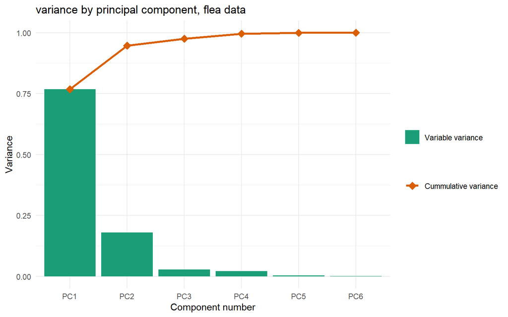

The user study task trys to explore the *full sample, full dimensionality* $[n,p]$ seperation of two specified clusters. In an analogous manner, **let’s try to create a screeplot-like output to evalute the contributions of the original variables.** Note that this is related to what R. Fisher is attempting in his 1936 paper. Similarly we start by finding cluster means and covariances.

**Cluster means:**

|  | tars1 | tars2 | head | aede1 | aede2 | aede3 |
| --- | --- | --- | --- | --- | --- | --- |
| Cluster means of: Concinna | 183.1 | 129.6 | 51.24 | 146.2 | 14.10 | 104.9 |
| Cluster means of: Heptapot. | 138.2 | 125.1 | 51.59 | 138.3 | 10.09 | 106.6 |
| Cluster means of: Heikert. | 201.0 | 119.3 | 48.87 | 124.7 | 14.29 | 81.0 |

**Cluster variance-covariance matrices:** For Concinna , Heptapot. , Heikert. respectively

|  | tars1 | tars2 | head | aede1 | aede2 | aede3 |
| --- | --- | --- | --- | --- | --- | --- |
| tars1 | 147.49 | 66.638 | 18.5262 | 15.081 | -5.2095 | 14.214 |
| tars2 | 66.64 | 51.248 | 11.5452 | 2.476 | -1.8119 | 3.093 |
| head | 18.53 | 11.545 | 4.9905 | 5.852 | -0.5238 | 5.486 |
| aede1 | 15.08 | 2.476 | 5.8524 | 31.662 | -0.9690 | 15.629 |
| aede2 | -5.21 | -1.812 | -0.5238 | -0.969 | 0.7905 | -1.986 |
| aede3 | 14.21 | 3.093 | 5.4857 | 15.629 | -1.9857 | 38.229 |

|  | tars1 | tars2 | head | aede1 | aede2 | aede3 |
| --- | --- | --- | --- | --- | --- | --- |
| tars1 | 87.3268 | 44.5498 | 20.5260 | 19.1732 | -0.7359 | 15.2879 |
| tars2 | 44.5498 | 73.0390 | 15.7056 | 14.0216 | -0.3896 | 21.2294 |
| head | 20.5260 | 15.7056 | 8.0628 | 8.2121 | -0.2944 | 4.9675 |
| aede1 | 19.1732 | 14.0216 | 8.2121 | 17.1602 | -0.5022 | 7.9264 |
| aede2 | -0.7359 | -0.3896 | -0.2944 | -0.5022 | 0.9437 | 0.2771 |
| aede3 | 15.2879 | 21.2294 | 4.9675 | 7.9264 | 0.2771 | 34.2532 |

|  | tars1 | tars2 | head | aede1 | aede2 | aede3 |
| --- | --- | --- | --- | --- | --- | --- |
| tars1 | 222.133 | 63.4000 | 22.6000 | 30.3667 | 4.3667 | 29.467 |
| tars2 | 63.400 | 44.1591 | 7.9097 | 11.8183 | 0.3366 | 11.467 |
| head | 22.600 | 7.9097 | 5.5161 | 5.6860 | 0.0054 | 4.233 |
| aede1 | 30.367 | 11.8183 | 5.6860 | 21.3699 | -0.3269 | 11.700 |
| aede2 | 4.367 | 0.3366 | 0.0054 | -0.3269 | 1.2129 | 1.267 |
| aede3 | 29.467 | 11.4667 | 4.2333 | 11.7000 | 1.2667 | 79.733 |

Suppose the clusters in questions are *Concinna* and *Heptapot*. The line between the the cluster means of these groups is their difference. This is sufficeint for Linear Discriminant Analysis (LDA) which assumes homogenious variation between clusters. We’ll follow Fisher’s Discriminant Analysis, which accounts for within cluster variance.

$$Cluster Seperation_{[1,p]} = (\mu_{b[1,p]} - \mu_{a[1,p]})^2~/~(\Sigma_{a[p, p]} + \Sigma_{b[p, p]})~~~;~a,~b~are~clusters \in X_{[n,p]}$$

| var | var_clSep | cumsum_clSep |
| --- | --- | --- |
| head | 21.16 | 21.16 |
| aede1 | 10.36 | 31.53 |
| aede2 | 4.68 | 36.20 |
| aede3 | 3.65 | 39.85 |
| tars2 | 2.51 | 42.36 |
| tars1 | 0.64 | 43.01 |

We discard the sign as we only care about magnitude each variable contributed to the seperation of the specified clusters. We scale the absolute terms by the inverse of the sumation. Now let’s visualize this similar to the screeplot.

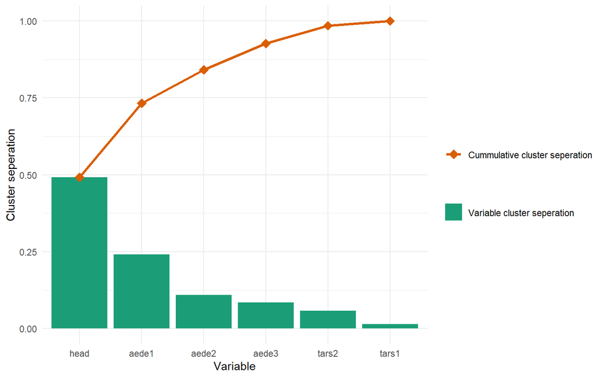

## Evaluating the response

Now that we have a measure we want to define an objective cutoff for evaluation. We want the measure to a few attributes:

- Continuous relative to the cluster seperation
- Sum of squares should equal 1
- Symetric, diverging around uniform weight

Following these, we define a measure to be:

$$Marks = \sum_{i = 1}^{p}(\sqrt{ClusterSeperation_i} - (1 / (p - 1)) * I(Response_i)$$

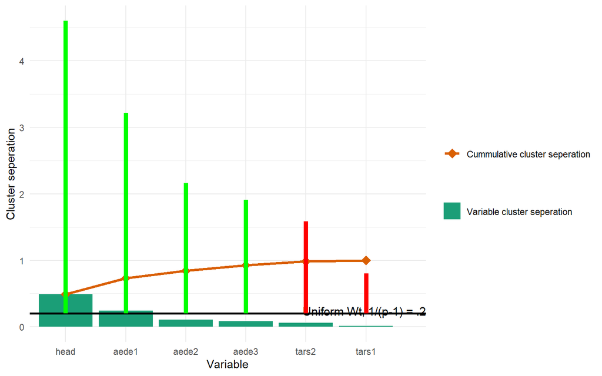

Here, we add lines indicating the weight of each variable if selected as important. we then apply our measure to evalue task responses, we review an example response below:

| variable | var_clSep | Weight | exampleResponse | Marks |
| --- | --- | --- | --- | --- |
| head | 21.16 | 4.40 | 1 | 4.40 |
| aede1 | 10.36 | 3.02 | 1 | 3.02 |
| aede2 | 4.68 | 1.96 | 0 | 0.00 |
| aede3 | 3.65 | 1.71 | 1 | 1.71 |
| tars2 | 2.51 | 1.39 | 0 | 0.00 |
| tars1 | 0.64 | 0.60 | 1 | 0.60 |

Total Marks = 9.73

## Projected data view

All linear projections are nesciarily a lossy representation of the full data. By this we mean that no single 2D frame can show the whole set of infromation for $p>=3$ -dimensional sample. Any pair of Pricipal Components nessciaronly shows less than all the variation, namely the sum of their contributions, typicaly stated as percentage of full sample variation. Analogously any single projection cannot show the full information explain the cluster seperation of 2 given clusters.

## Cluster seperation on single-variable permuted data

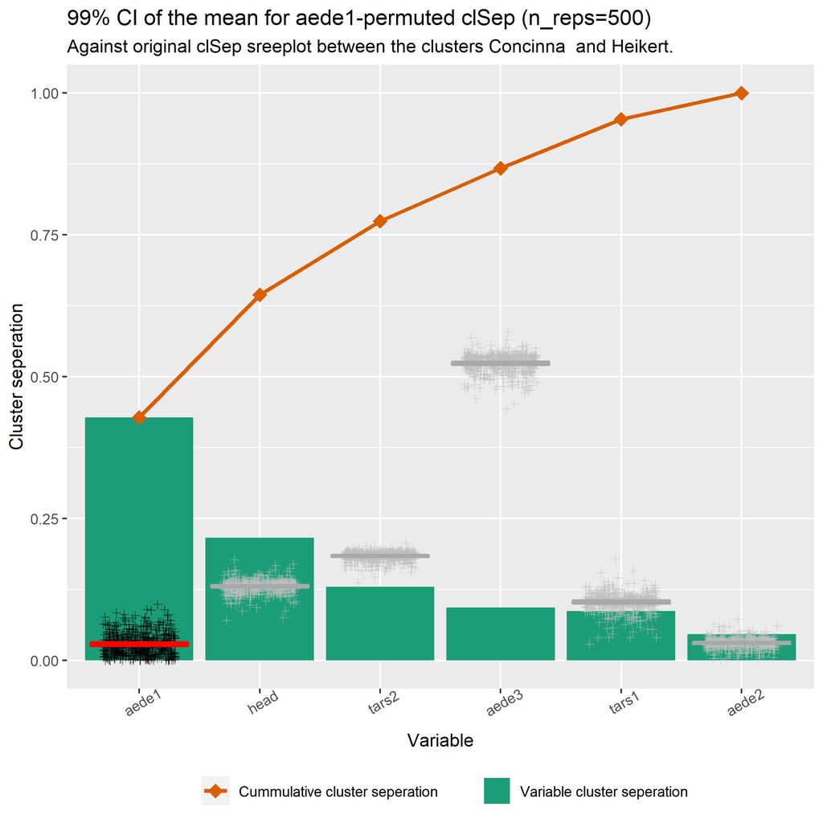

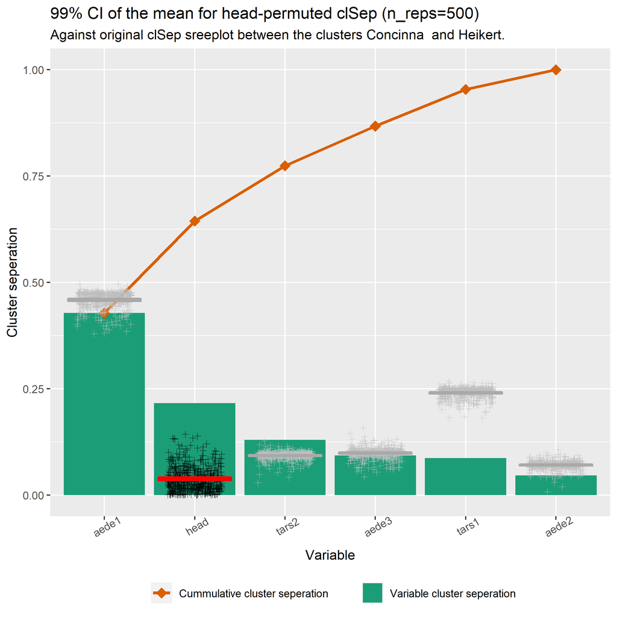

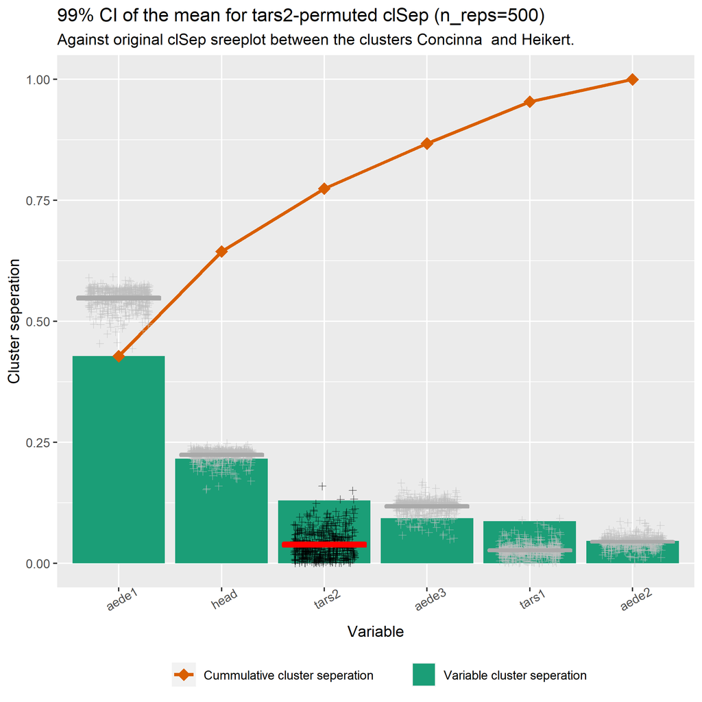

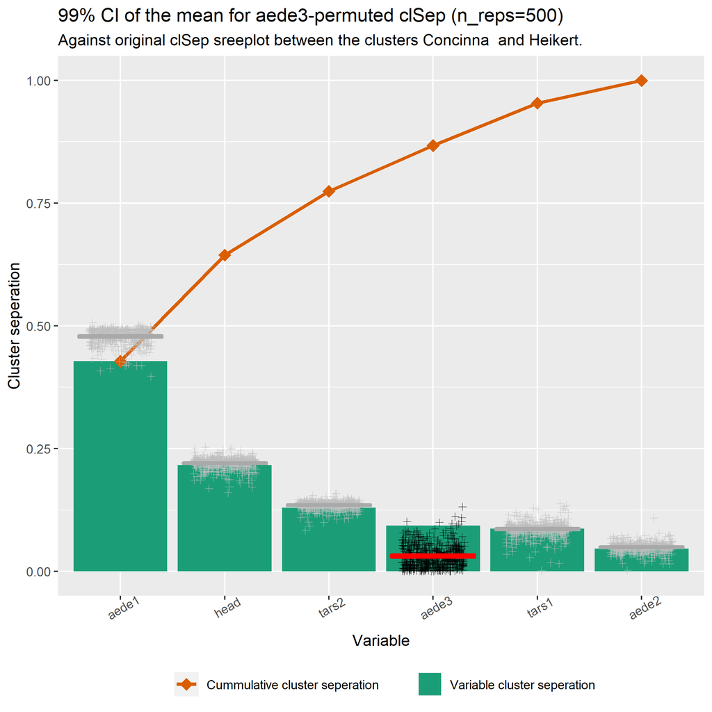

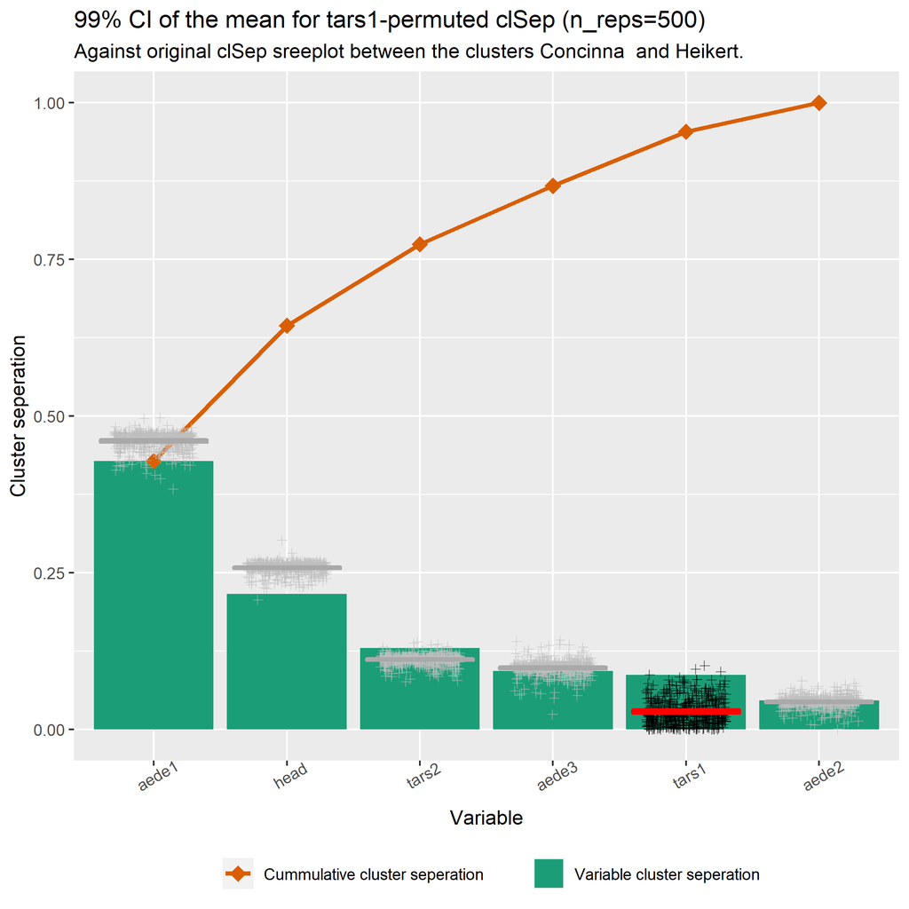

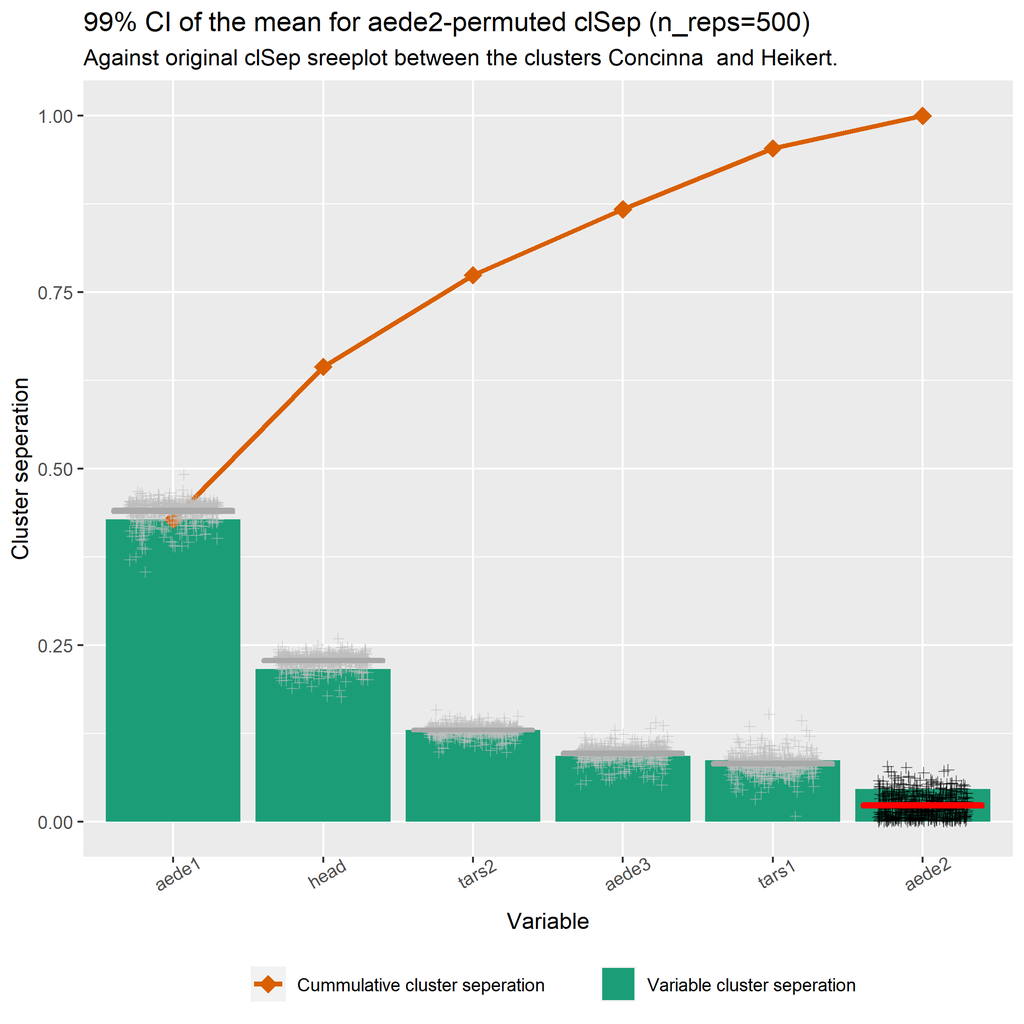

## Application to other toy sets

In order to stress test this Cluster seperation viewed by a screeplot we apply it to other toy datasets.

### Penguins, between 2 levels of spieces

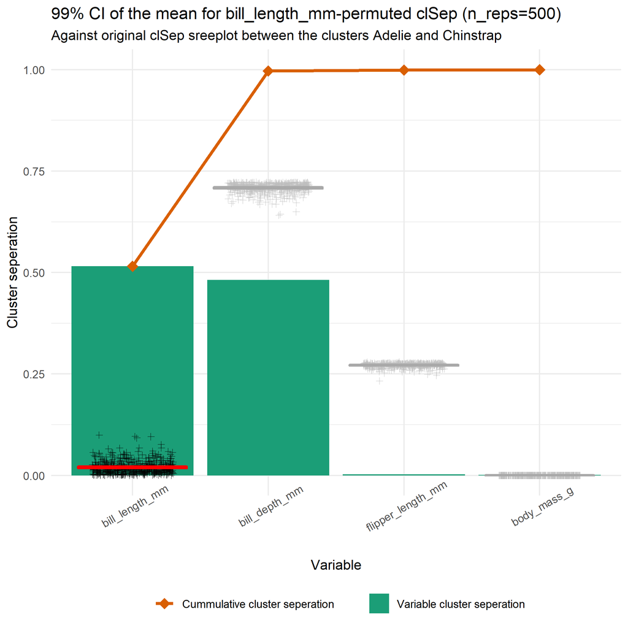

### Penguins, between 2 levels of sex (invalid)

(invalid assumptions, as there are 3 species clusters for each sex)

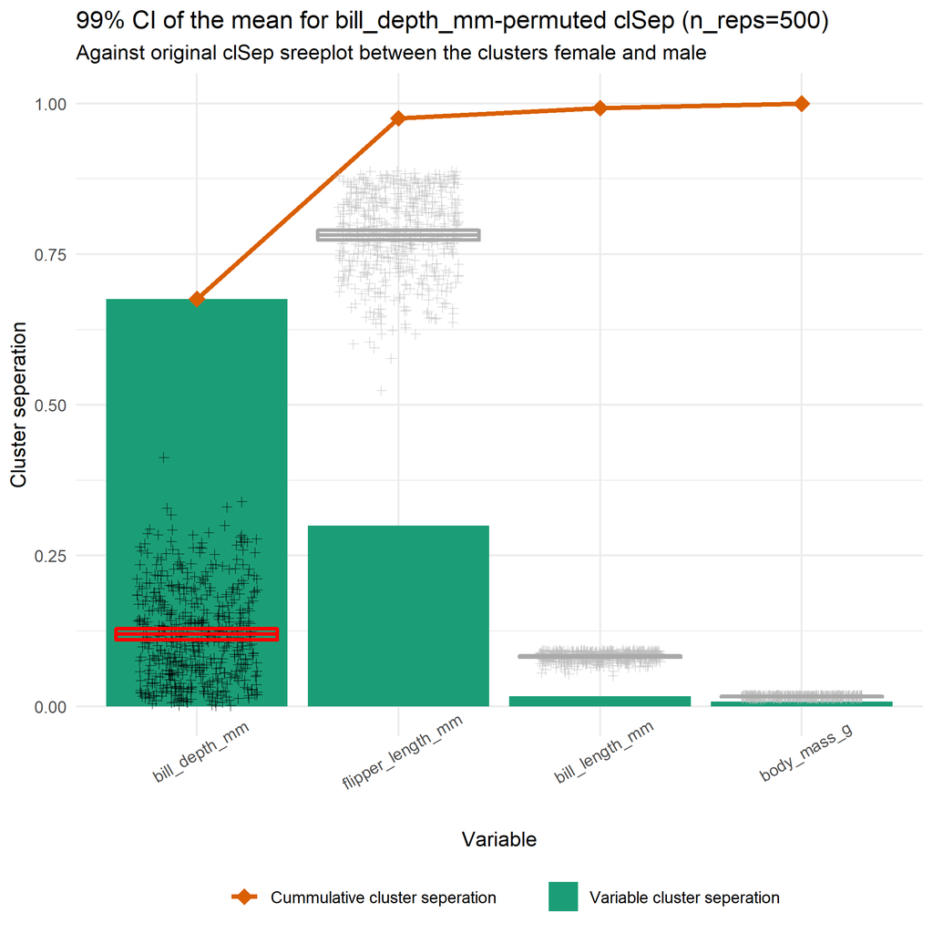

### Penguins, between 2 levels of sex with 1 species

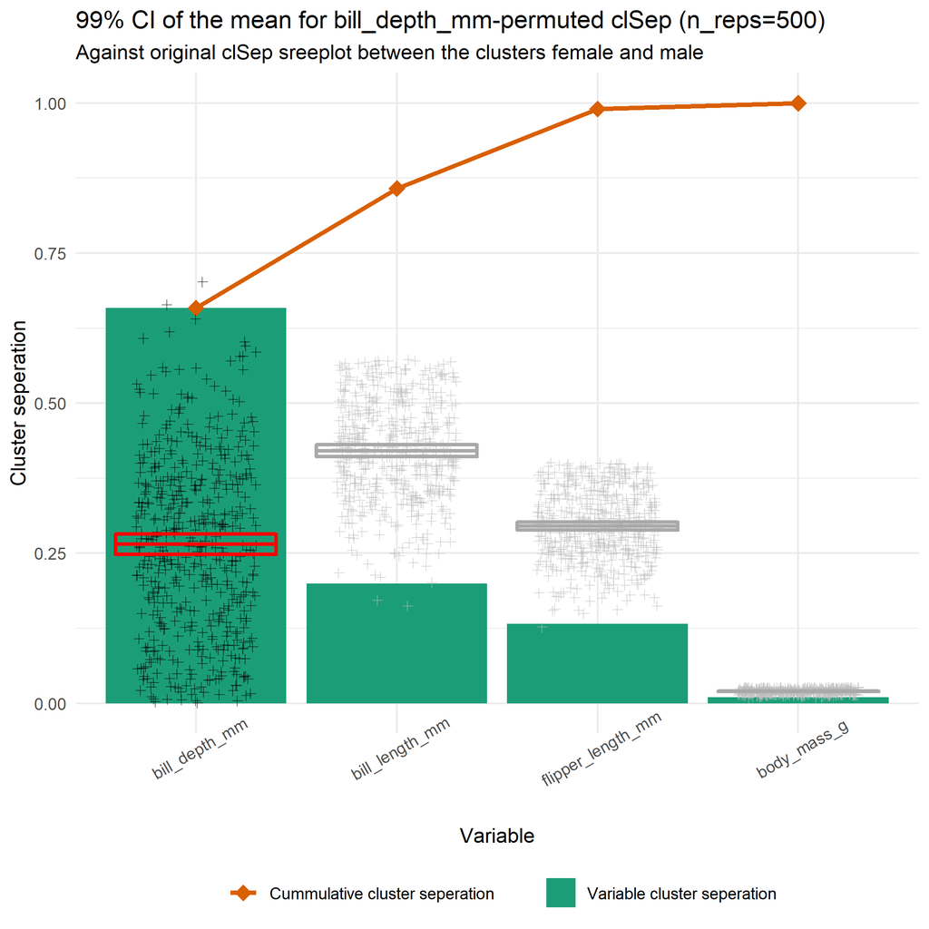

### Wine, between 2 levels of type of wine

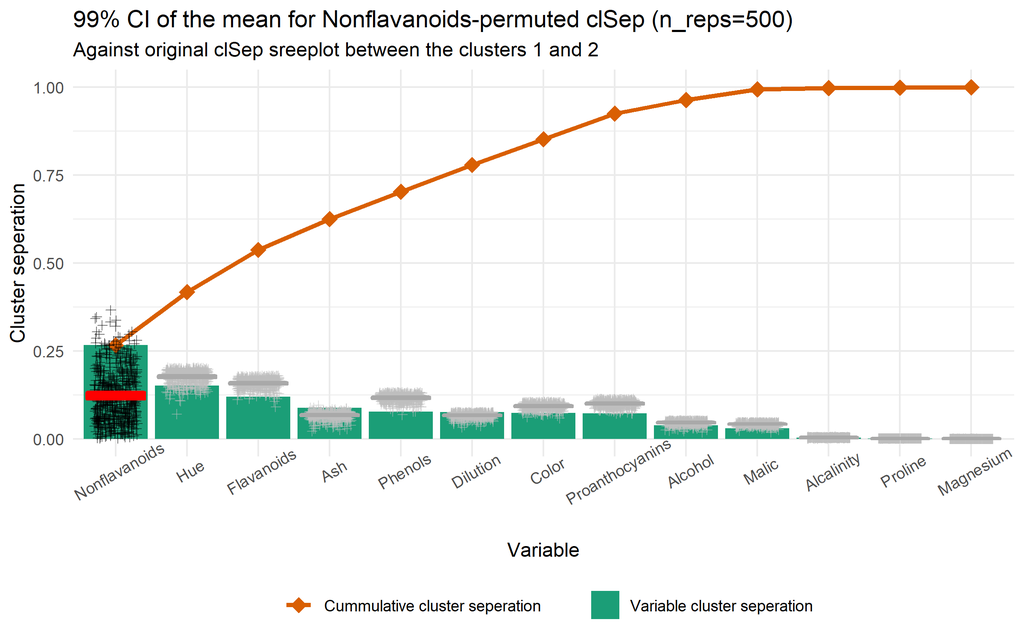

### Breastcancer, between benign/malignant tumors

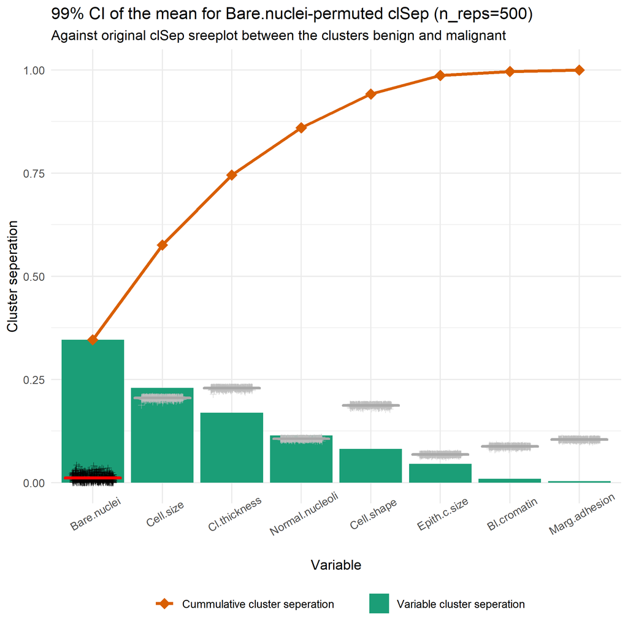

### Olive, between 2 levels of region of Italy

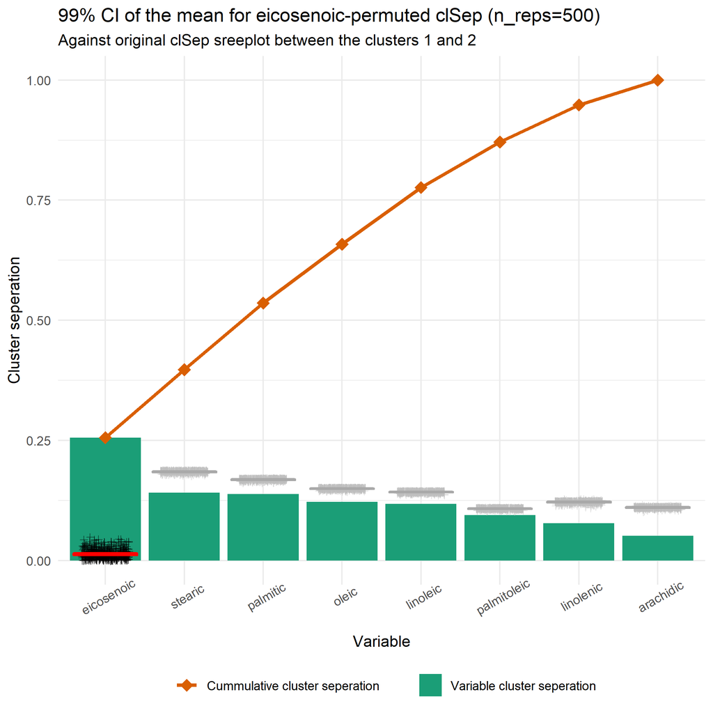

### Rat CNS gene expression, between 2 levels of “the high-level classes”

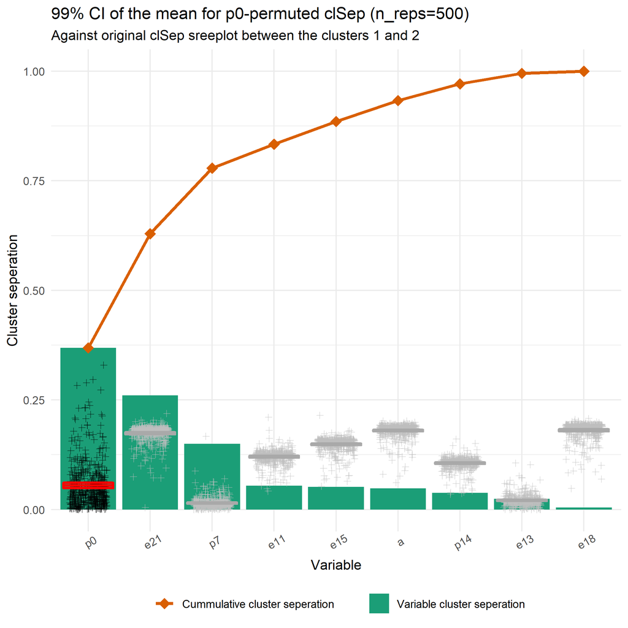

# Simulation difficulty

In order to properly distinguish a difference between the 3 vizualization factors the data must be of suitable complexity, such that it has the following properties:

1. Must be complex enough not to see within the any pair of the first 4 Principal Components; such that PCA is not sufficent for exploring cluster seperation
2. Must not be so complex as to preclude any meaningful response given the factor visuals and time constraints.

Let’s try to evaluate our current generation of data simulations against these properties

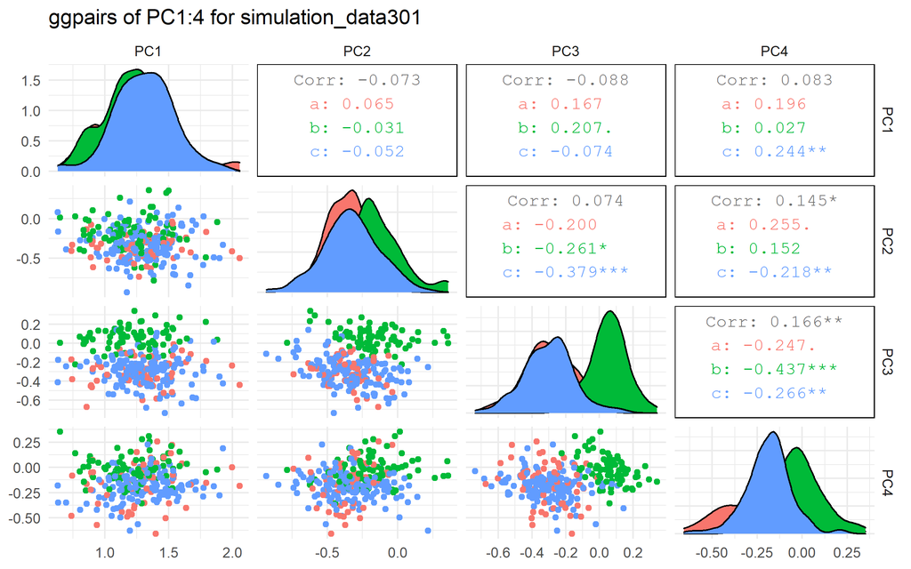

*note: spinifex needs cleanup*

# References

Fisher, Ronald A. “The Use of Multiple Measurements in Taxonomic Problems.” Annals of Eugenics 7, no. 2 (September 1936): 179-88. https://doi.org/10.1111/j.1469-1809.1936.tb02137.x.